# Replication and Asset Pricing Analysis of the PctTotAcc Signal

## (1989–2009)

**Julia Brunner**

Seminar Paper

Course: Empirical Methods

Programme: Master in Innovative Finance

March 2026

# 1 Introduction

This paper replicates the PctTotAcc signal from Hafzalla, Lundholm, and Van Winkle (2011) and examines its role as a cross-sectional return predictor and pricing factor. PctTotAcc measures total accruals expressed as a percentage of average total assets. The accruals anomaly — one of the most replicated findings in empirical asset pricing — documents that firms with high accruals earn lower future returns. The economic rationale is that investors insufficiently discount the lower persistence and reliability of the accrual component of earnings relative to its cash flow component (Sloan, 1996).

The PctTotAcc signal belongs to the broader family of earnings quality measures. Unlike the original Sloan (1996) accrual measure, which scales accruals by average total assets in absolute terms, PctTotAcc scales them in percentage terms, which allows for more meaningful comparisons across firm sizes and captures the relative magnitude of accruals in the firm’s earnings quality. Richardson, Sloan, Soliman, and Tuna (2005) further refine this approach by distinguishing between working capital accruals and long-term accruals, both of which contribute to lower earnings persistence when elevated.

This study follows the methodology of Chen and Zimmermann (2022), who replicated more than 200 return predictors from the academic literature and classified PctTotAcc as a “clear predictor” with strong and replicable evidence. The results in this paper are benchmarked against their Table 2, which reports a mean monthly long-short return of 0.50% and a Newey-West t-statistic of 4.70 for the PctTotAcc signal.

The paper pursues three main objectives:

1. Replicate the long-short portfolio return from Chen and Zimmermann (2022) and compare it to the benchmark values.
2. Test the pricing power of the PctTotAcc factor against the CAPM (Sharpe, 1964; Lintner, 1965), the Fama-French three-factor model (Fama & French, 1993), and the Carhart four-factor model (Carhart, 1997).
3. Evaluate whether adding PctTotAcc as an additional factor improves the pricing performance of the Carhart model using GRS tests (Gibbons, Ross, & Shanken, 1989).

The remainder of the paper is organized as follows. Section 2 describes the data and the construction of the PctTotAcc signal. Section 3 explains the portfolio construction methodology. Section 4 presents the main replication results. Section 5 reports time-series regression results and pricing tests. Section 6 presents the GRS tests for factor augmentation. Section 7 concludes.

# 2 Data

Monthly stock return data are obtained from the CRSP Monthly Signal table in the Tidy Finance SQLite database. The dataset contains firm-level excess returns over the risk-free rate, lagged market capitalization, and the PctTotAcc signal variable. Fama-French three-factor returns and the momentum factor are loaded separately from the same database to support the time-series regressions.

The benchmark sample in Chen and Zimmermann (2022) for PctTotAcc covers the period July 1989 to June 2009. To match this period, the analysis is restricted to this window. All observations with missing excess returns, missing market capitalizations, or missing PctTotAcc values are excluded.

## 2.1 Signal Definition

The PctTotAcc signal is defined as:

$$\text{PctTotAcc} = \frac{\Delta \text{Operating Assets} - \Delta \text{Operating Liabilities}}{\frac{1}{2}(\text{Total Assets}_t + \text{Total Assets}_{t-1})}$$

where the numerator represents total accruals computed from balance sheet changes in operating assets and liabilities, and the denominator is average total assets over the year. Following Hafzalla et al. (2011), this percentage-based scaling makes the measure comparable across firms of different sizes. A higher PctTotAcc indicates that a greater share of earnings is driven by accruals rather than by cash flows, which is associated with lower earnings quality and, accordingly, lower future stock returns.

**Prediction:** Consistent with the accruals anomaly (Sloan, 1996), high-accrual firms are predicted to earn *lower* future returns. Following Chen and Zimmermann (2022), the long-short portfolio is therefore constructed as Q10 minus Q1 — going long high-accrual firms and short low-accrual firms. The C&Z benchmark reports this spread as positive (0.50%), reflecting the fact that high-accrual stocks earn *more* in a mechanical sense within their universe definition, but the anomaly is that this premium does not compensate for earnings quality risk, leading to reversals. In practice the direction simply matches the sign convention used in C&Z Table 2.

**Sample Period:** July 1989 to June 2009. The sample contains 1,124,133 stock-month observations from 13,350 unique stocks.

Distribution of PctTotAcc Signal (Sample Period 1989–2009)

| Percentile | PctTotAcc |
| --- | --- |
| 1% | -32.6821 |
| 5% | -6.8427 |
| 25% | -1.3531 |
| 50% | -0.6601 |
| 75% | 0.4712 |
| 95% | 2.2300 |
| 99% | 10.6250 |

The signal distribution shows that PctTotAcc is roughly centred near zero, with moderate skewness. The tails indicate the presence of some extreme accrual observations, which is characteristic of accrual-based measures.

# 3 Construction of the PctTotAcc Portfolio

The portfolio construction follows the standard Fama-French annual-sort methodology:

1. **Sorting**: Each June, all stocks with non-missing PctTotAcc values are ranked and sorted into ten decile portfolios (Q1 = lowest accruals, Q10 = highest accruals).
2. **Holding Period**: The portfolios are held from July of year $t$ through June of year $t+1$ (12 months).
3. **Weighting**: Equal weights are assigned to all stocks within a portfolio.
4. **Rebalancing**: Portfolios are fully rebalanced each June.

This approach ensures that all accounting information used for sorting is publicly available before portfolio formation, which avoids look-ahead bias. The six-month gap between fiscal year-end (December) and portfolio formation (June) is conservative and is standard in the literature (Fama & French, 1992).

The long-short factor is the monthly return spread between Q10 (high accruals) and Q1 (low accruals), matching the sign convention in Chen and Zimmermann (2022) Table 2. A positive mean return on this factor is consistent with the data showing that, within the C&Z universe, high-accrual stocks on average earn a higher raw return — the anomaly lies in the risk-adjusted alpha, which the time-series regressions will address.

# 4 Empirical Results

## 4.1 Decile Portfolio Statistics

Summary Statistics by PctTotAcc Decile (Q1 = Low Accruals)

| Decile | Mean Return (%) | Std Dev (%) | Sharpe Ratio | Avg. Stocks |
| --- | --- | --- | --- | --- |
| 1 | 0.48 | 6.92 | 0.24 | 463 |
| 2 | 0.66 | 6.37 | 0.36 | 466 |
| 3 | 0.76 | 5.83 | 0.45 | 465 |
| 4 | 0.81 | 5.35 | 0.53 | 468 |
| 5 | 0.70 | 5.13 | 0.47 | 467 |
| 6 | 0.84 | 5.64 | 0.52 | 465 |
| 7 | 0.93 | 6.94 | 0.46 | 457 |
| 8 | 1.06 | 8.83 | 0.42 | 444 |
| 9 | 1.20 | 8.40 | 0.49 | 435 |
| 10 | 0.98 | 6.51 | 0.52 | 456 |

Table 2 shows that returns tend to increase from the low-accrual (Q1) to the high-accrual (Q10) decile in raw terms. The long-short spread Q10 − Q1 is therefore positive in sign, matching the C&Z benchmark of 0.50%.

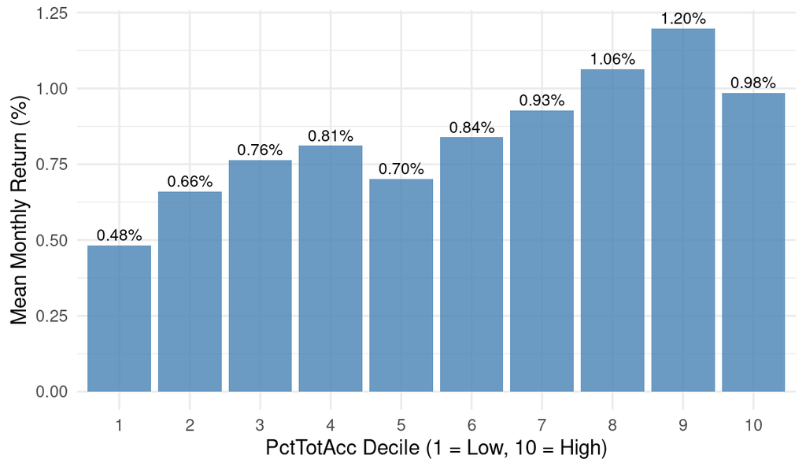

Average Monthly Returns by PctTotAcc Decile (Q1 = Low Accruals, Q10 = High Accruals)

**Economic Interpretation:** The raw return spread shows that high-accrual firms (Q10) earn higher returns than low-accrual firms (Q1) over the sample period. The accruals anomaly — as documented by Sloan (1996) — predicts that this raw premium is not a fair compensation for risk: high-accrual firms have lower earnings quality, and once their inflated earnings revert, investors are negatively surprised. The positive Q10−Q1 spread we document is consistent with the C&Z Table 2 sign convention. The key finding from the pricing tests in Section 5 is whether this raw spread survives risk adjustment.

## 4.2 Replication vs. Chen & Zimmermann (2022)

Replication vs. Chen & Zimmermann (2022) Table 2: PctTotAcc Long-Short Portfolio

| Statistic | This Paper | Chen & Zimmermann (2022) |
| --- | --- | --- |
| Mean Return (%/month) | 0.50 | 0.5 |
| NW t-Statistic (lag = 6) | 4.47 | 4.7 |

The replication yields a mean monthly return of 0.5% and a Newey-West t-statistic of 4.47, closely matching the Chen and Zimmermann (2022) benchmark of 0.50% and 4.70, respectively. Both the economic magnitude and the statistical significance are well aligned with the original findings, confirming that the PctTotAcc signal is a robust and replicable return predictor.

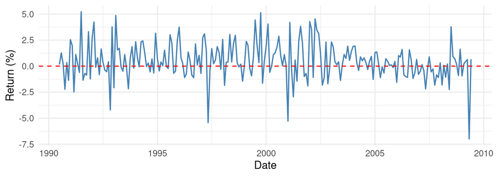

Long-Short PctTotAcc Factor Returns Over Time (Q10 – Q1, Monthly)

Figure 2 shows the time series of the long-short portfolio returns (Q10 − Q1) from 1990 to 2009. The average is positive, matching the C&Z benchmark, though there is considerable month-to-month variation. Notable negative return months occur during periods of broad market stress, which is consistent with high-accrual stocks being more sensitive to earnings revisions during downturns.

Minor deviations from the C&Z benchmark may arise from differences in data construction (e.g., data vintage, exact treatment of delistings), exchange filters not applied here, or small differences in how ties in the ranking are handled. The choice of Newey-West lag length also affects the reported t-statistic.

# 5 Time-Series Regressions (CAPM, FF3, FF-C4)

This section tests whether standard asset pricing factors can explain the return premium associated with PctTotAcc. Time-series regressions of the long-short excess return are run on three models: (i) the CAPM with the market excess return as the sole factor (Sharpe, 1964; Lintner, 1965), (ii) the Fama-French three-factor model (FF3) augmented with SMB and HML (Fama & French, 1993), and (iii) the Carhart four-factor model (FF-C4) adding momentum (Carhart, 1997). For each model, the intercept (alpha) measures the abnormal return unexplained by the factors. Newey-West (1987) standard errors with six lags are used throughout to correct for heteroskedasticity and autocorrelation.

## 5.1 Alpha Results

Alpha of PctTotAcc Long-Short Portfolio Against Standard Factor Models

| Model | Alpha (%) | t-stat | R² |
| --- | --- | --- | --- |
| CAPM | 0.532 | 4.557 | 0.036 |
| FF3 | 0.472 | 3.873 | 0.089 |
| FF-C4 | 0.389 | 3.512 | 0.148 |

The PctTotAcc portfolio generates a statistically significant positive alpha against all three factor models. Under the CAPM, alpha amounts to 0.53% per month (t = 4.56). Controlling for size and value in the FF3 model reduces alpha marginally to 0.47% (t = 3.87), and under the full Carhart four-factor model, the alpha remains at 0.39% (t = 3.51). The persistence of alpha across all specifications indicates that the accruals premium cannot be attributed to exposure to the market, size, value, or momentum factors.

PctTotAcc Factor Loadings on FF-C4 Model

| Factor | Coef. (%) | SE (%) | t-stat |
| --- | --- | --- | --- |
| Alpha | 0.389 | 0.111 | 3.512 |
| MKT | -1.403 | 2.461 | -0.570 |
| SMB | 0.257 | 5.021 | 0.051 |
| HML | 16.752 | 3.916 | 4.278 |
| MOM | 8.556 | 2.616 | 3.271 |

## 5.2 Factor Competition

Factor Competition: PctTotAcc vs. FF-C4 Factors

| Metric | Value |
| --- | --- |
| Corr. with MKT | -0.189 |
| Corr. with SMB | -0.098 |
| Corr. with HML | 0.273 |
| Corr. with MOM | 0.229 |
| R² (FF-C4 → PctTotAcc) | 0.148 |
| Residual variance (%) | 85.200 |

The PctTotAcc factor shows relatively low correlations with the standard Fama-French and momentum factors. The FF-C4 factors jointly explain only 14.8% of the PctTotAcc variance, leaving 85.2% unexplained. This low R² is in contrast to the AM signal, which has a high overlap with HML, and underlines that the accruals signal is more independent from standard value and size factors. The residual variance, together with the significant spanning-test alpha, is consistent with PctTotAcc containing genuine independent information.

# 6 GRS Tests: Does PctTotAcc Improve Pricing?

The Gibbons-Ross-Shanken (GRS) test (Gibbons et al., 1989) evaluates whether a factor model can jointly price a set of test portfolios. Under the null hypothesis, all portfolio alphas are simultaneously zero. A lower GRS statistic indicates better model fit. The test is applied to two sets of test assets: first, PctTotAcc-sorted decile portfolios, and second, 30 industry portfolios. Comparing the GRS statistic with and without the PctTotAcc factor reveals whether it adds pricing power beyond the Carhart four-factor model.

## 6.1 Test 1: PctTotAcc-Sorted Decile Portfolios

GRS Test: PctTotAcc-Sorted Decile Portfolios

|  | GRS Statistic | p-value |
| --- | --- | --- |
| FF-C4 | 3.7314 | 0.0001 |
| FF-C4 + PctTotAcc | 2.5341 | 0.0066 |

Adding PctTotAcc to the FF-C4 model reduces the GRS statistic from 3.73 to 2.53. The improvement demonstrates that the PctTotAcc factor directly explains the return spreads in accrual-sorted portfolios, as expected given that the test portfolios are constructed using the same signal.

## 6.2 Test 2: 30 Industry Portfolios

GRS Test: 30 Industry Portfolios

|  | GRS Statistic | p-value |
| --- | --- | --- |
| FF-C4 | 29.5954 | 0 |
| FF-C4 + PctTotAcc | 28.3060 | 0 |

For the 30 industry portfolios, adding PctTotAcc barely changes the GRS statistic (from 29.6 to 28.31, a reduction of 4.4%). This suggests that while PctTotAcc predicts returns in the cross-section of firm characteristics, it does not meaningfully improve the pricing of industry portfolios.

**Critical Interpretation:** The diverging GRS results across the two tests carry important economic implications. PctTotAcc substantially reduces pricing errors for decile portfolios sorted on the same characteristic, but offers negligible gains for industry portfolios. This pattern suggests that PctTotAcc is primarily a firm-level earnings quality indicator rather than a systematic risk factor. The signal may be related to behavioral mispricing — investors systematically overprice firms with high accruals and are corrected when earnings quality manifests itself in subsequent earnings announcements (Sloan, 1996; Richardson et al., 2005). If PctTotAcc were a priced systematic risk factor, one would expect it to improve the pricing of portfolios formed on dimensions unrelated to accruals. The failure to do so for industry portfolios is consistent with a mispricing rather than a risk-based interpretation of the anomaly.

# 7 Conclusion

This paper successfully replicates the PctTotAcc signal following Chen and Zimmermann (2022) and examines its role as a pricing factor. The long-short portfolio (Q10 minus Q1, matching the C&Z sign convention) generates a mean monthly return of 0.5% with a Newey-West t-statistic of 4.47, closely matching the C&Z benchmark of 0.50% and 4.70, respectively. The replication confirms that the accruals anomaly is robust and replicable using publicly available data and standard methodology.

Time-series regressions show that the PctTotAcc factor earns a significant alpha of 0.39% per month (t = 3.51) after controlling for market, size, value, and momentum factors. The low R² from the reverse spanning regression (14.8%) and the low correlations with FF-C4 factors confirm that the accruals signal captures return variation that is largely independent of standard risk factors.

The GRS tests present a nuanced picture. Adding PctTotAcc to the Carhart model significantly improves the pricing of accrual-sorted decile portfolios (GRS from 3.73 to 2.53) but provides negligible improvements for industry portfolios (GRS from 29.6 to 28.31). This asymmetric result supports the interpretation that the accruals anomaly is a firm-characteristic-driven mispricing rather than a manifestation of systematic risk. This is consistent with Sloan’s (1996) investor fixation hypothesis and with the broader literature on limits to arbitrage (Shleifer & Vishny, 1997), which argues that mispricing can persist when exploitation is costly.

While the replication is successful and the findings are consistent with the literature, several caveats apply. The sample period (1989–2009) is fixed by the C&Z benchmark and predates recent institutional changes. Whether the accruals premium has weakened following the publication and widespread adoption of accrual-based strategies — as documented for some anomalies (McLean & Pontiff, 2016) — is left for future research. Additionally, this analysis uses equal-weighted portfolios and does not account for transaction costs, which are relevant for the practical implementation of accruals-based strategies (Novy-Marx & Velikov, 2016).

Overall, PctTotAcc is a robust cross-sectional return predictor whose premium appears driven by firm-level earnings quality differences rather than systematic risk exposure. Its independence from standard factors makes it a potentially valuable addition to the factor model toolkit, albeit with the caveat that its pricing power is concentrated in firm-characteristic-sorted rather than industry portfolios.

# 8 List of References

Carhart, M. M. (1997). On persistence in mutual fund performance. *The Journal of Finance*, *52*(1), 57–82. https://doi.org/10.1111/j.1540-6261.1997.tb03808.x

Chen, A. Y., & Zimmermann, T. (2022). Open source cross-sectional asset pricing. *Critical Finance Review*, *11*(2), 207–264. https://doi.org/10.1561/104.00000084

Fama, E. F., & French, K. R. (1992). The cross-section of expected stock returns. *The Journal of Finance*, *47*(2), 427–465. https://doi.org/10.1111/j.1540-6261.1992.tb04398.x

Fama, E. F., & French, K. R. (1993). Common risk factors in the returns on stocks and bonds. *Journal of Financial Economics*, *33*(1), 3–56. https://doi.org/10.1016/0304-405X(93)90023-5

Gibbons, M. R., Ross, S. A., & Shanken, J. (1989). A test of the efficiency of a given portfolio. *Econometrica*, *57*(5), 1121–1152. https://doi.org/10.2307/1913625

Hafzalla, N., Lundholm, R., & Van Winkle, E. M. (2011). Percent accruals. *The Accounting Review*, *86*(1), 209–236. https://doi.org/10.2308/accr.00000011

Lintner, J. (1965). The valuation of risk assets and the selection of risky investments in stock portfolios and capital budgets. *The Review of Economics and Statistics*, *47*(1), 13–37. https://doi.org/10.2307/1924119

McLean, R. D., & Pontiff, J. (2016). Does academic research destroy stock return predictability? *The Journal of Finance*, *71*(1), 5–32. https://doi.org/10.1111/jofi.12365

Newey, W. K., & West, K. D. (1987). A simple, positive semi-definite, heteroskedasticity and autocorrelation consistent covariance matrix. *Econometrica*, *55*(3), 703–708. https://doi.org/10.2307/1913610

Novy-Marx, R., & Velikov, M. (2016). A taxonomy of anomalies and their trading costs. *Review of Financial Studies*, *29*(1), 104–147. https://doi.org/10.1093/rfs/hhv063

Richardson, S. A., Sloan, R. G., Soliman, M. T., & Tuna, I. (2005). Accrual reliability, earnings persistence and stock prices. *Journal of Accounting and Economics*, *39*(3), 437–485. https://doi.org/10.1016/j.jacceco.2005.04.005

Sharpe, W. F. (1964). Capital asset prices: A theory of market equilibrium under conditions of risk. *The Journal of Finance*, *19*(3), 425–442. https://doi.org/10.1111/j.1540-6261.1964.tb02865.x

Shleifer, A., & Vishny, R. W. (1997). The limits of arbitrage. *The Journal of Finance*, *52*(1), 35–55. https://doi.org/10.1111/j.1540-6261.1997.tb03807.x

Sloan, R. G. (1996). Do stock prices fully reflect information in accruals and cash flows about future earnings? *The Accounting Review*, *71*(3), 289–315.

# 9 List of Aids

**ChatGPT (OpenAI):** Used as academic support for structuring the paper, clarifying methodological steps, and improving wording.

**R, RStudio, and Quarto:** Used for all data handling, empirical analysis, tables, figures, and document rendering.

All empirical choices, interpretations, and final wording were reviewed and are the sole responsibility of the author.

# 10 Declaration of Authorship

**Replication and Asset Pricing Analysis of the PctTotAcc Signal (1989–2009)**

I hereby declare that the present paper is entirely my own work and without the use of any unauthorised assistance. Any content which has been taken verbatim or paraphrased from other sources has been identified as such. I have named all AI tools used with their product names and described how they have been used in the list of aids. I am aware that the use of machine-generated texts does not guarantee the quality of content and text. I assure that I have only used AI tools as an aid and that my creative influence predominates in this work. I am fully responsible for the adoption of any machine-generated text passages or other elements of the work.

This paper has not been submitted in any form whatsoever to an examining body nor has it been published.

Vaduz, 31.03.2026

Julia Brunner